**S/W Installation Guide (CPU)**

By Prof. Seungchul Lee  
http://iai.postech.ac.kr/  
Industrial AI Lab at POSTECH

Table of Contents

# 1. Overview

- Contents
  - deals with installment of packages for machine learning and deep learning
- OS
  - Even though TensorFlow packages are somehow proper in Linux type of OS,
  - This manual provides you in Windows 10 for users' convenience
- GPU
  - TensorFlow enables to utilize GPU parallel computing with CUDA
  - This manual handles CPU version's installment for convenience
- Anaconda
  - This manual doesn't use Anaconda to prevent collapsing between the packages

# 2. Requirements

- Windows 10, 64 bits PC (recommended)
- Python 3.7.2
- Visual C++ 2015 Redistributable (or 2017)
- Wheel files
  - fastcache, ecos
- Cautions
  - Windows display language should be in English
  - Delete Python or Anaconda if already installed
- Installation files
  - You can download all installation files including wheel files from the link below.
  - https://www.dropbox.com/sh/o0axet5wgyvz1c2/AAA9zE-PU9H7X1qaJAePvO3va?dl=1

# 3. Cautions

## 3.1. Windows 사용자명이 한글인 경우 (For Korean Students)

**[1]** 시작 $\rightarrow$ 다른 사용자 추가, 편집 또는 제거 검색

**[2]** 이 PC에 다른 사용자 추가

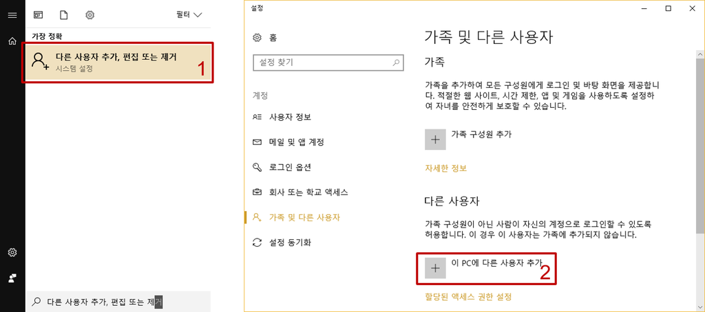

**[3]** 이 사람의 로그인 정보를 가지고 있지 않습니다 클릭

**[4]** Microsoft 계정 없이 사용자 추가 클릭

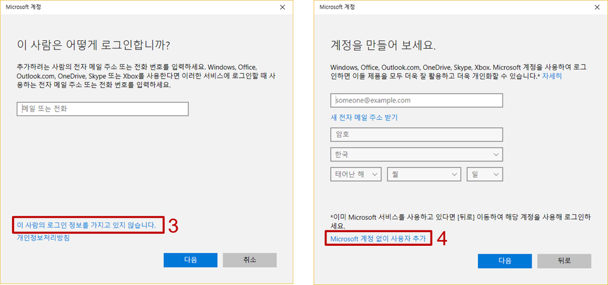

**[5]** 사용자명 입력 (영문, 띄어쓰기 X)

**[6]** 다음

**[7]** 계정 유형 변경

[figure not shown]

**[8]** 관리자 선택

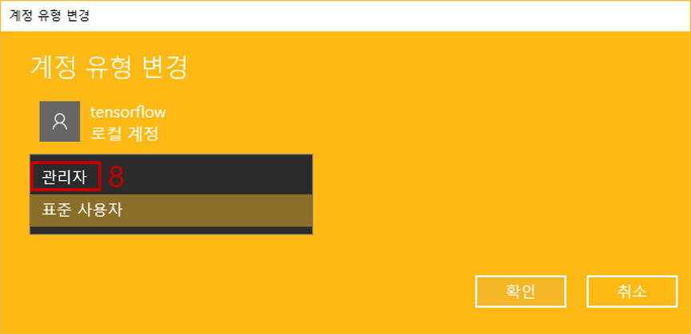

**[9]** 시작 메뉴에서 계정 아이콘 클릭

**[10]** 새로 만든 계정으로 로그인

[figure not shown]

## 3.2. If another version of Python or Anaconda installed

**[1]** Search $\rightarrow$ Advanced system settings  
**[2]** Click 'Environment Variables'

[figure not shown]

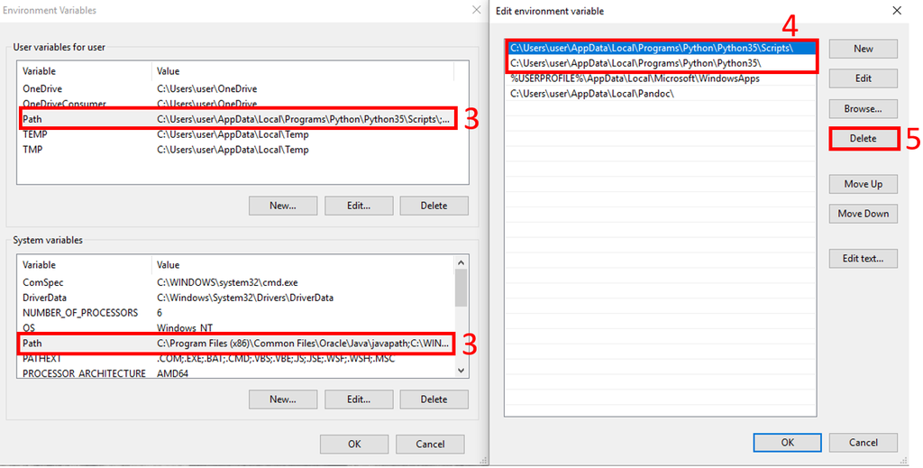

# 4. Environment Setup

- Get the installation files from the right link and make sure to unzip the files in **the same directory**

[figure not shown]

- Visual C++ 2015 Redistributable
  - Install vc_redist.x64.exe as attached
  - It doesn't need to be installed if the window shown in the right pops up

[figure not shown]

# 5. Python and its Packages Installation

- Python installation

  **[1]** Uncheck the first box and check the second one

  **[2]** Click 'Install Now'

[figure not shown]

- Package installation

  **[3]** Run command window with administrator privileges

[figure not shown]

  **[4]** Change directory to the directory where the installation files are located

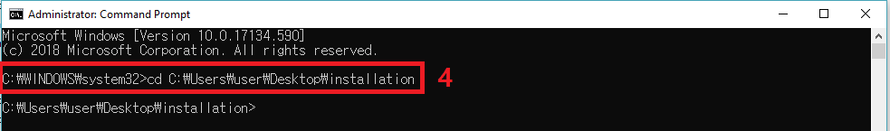

  **[5]** Run the following command `pip install --upgrade pip`

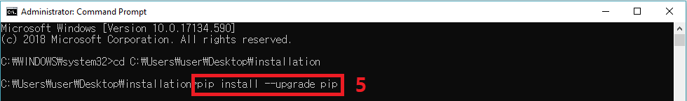

  **[6]** Run the following command `pip install numpy scipy`

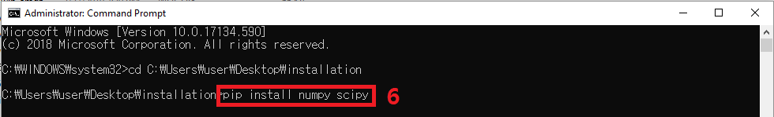

  **[7]** Run the following command `pip install toolz six seaborn scs scikit_learn pillow pandas matplotlib ipython dill jupyter tensorflow`

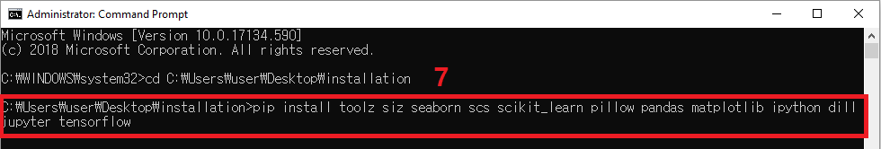

  **[8]** Copy the following command and paste it into the command window

  `pip install ecos-2.0.7.post1-cp37-cp37m-win_amd64.whl fastcache-1.0.2-cp37-cp37m-win_amd64.whl`

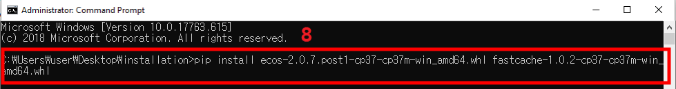

# 6. Setup Validation

- Running Jupyter Notebook

  **[1]** Type 'Jupyter notebook' in folder's domain

[figure not shown]

- Create Jupyter Notebook

  **[2]** Click 'New'

  **[3]** Select 'Python 3'

[figure not shown]

- Running code

  **[4]** Run the code after typing as below

  $\;\;\;\;$ Available by clicking the button or also with Ctrl+enter

[figure not shown]

# 7. Inquiries

- Please do not hesitate to contact below if you have any troubles.
  - Prof. Seungchul Lee (seunglee@postech.ac.kr)

```python
%%javascript
$.getScript('https://kmahelona.github.io/ipython_notebook_goodies/ipython_notebook_toc.js')
```